# Correlations in R

Correlations describe the strength of the relationship between two variables. How strong is the relationship? Is it positive? Is it negative?

R provides a number of different ways to calculate the correation between two variables. I’m going to walk you through some of the methods I like to use to calculate a correlation in R.

First, we’ll download the [PPIR](https://osf.io/rbwvq) datafile.

```r
#Load the foreign package so we can import an SPSS file
if (!require(foreign)){
  install.packages("foreign", dependencies = TRUE)
  require(foreign)
}
#load the SPSS file into a variable called 'dataset.' Now I can access the SPSS file just by referring to 'dataset'
dataset = read.spss("https://osf.io/rbwvq/download", to.data.frame=TRUE, use.value.labels = FALSE)
```

```
/var/folders/bc/pl1h20p92_z6drkkxgh4jv_00000gn/T//RtmpwnQyTe/file15a8424b8b017: Very long string record(s) found (record type 7, subtype 14), each will be imported in consecutive separate variables
```

```r
#make a new dataset variable with only participants that completed the experiment. Now I can do statistics on just the participants that completed the experiment.
datasetNoIncompletes <- subset (x = dataset, dataset$Finished==1)
```

Now we can access the PPIR data through the variable: datasetNoIncompletes

As is often the case, the [‘psych’](https://cran.r-project.org/web/packages/psych/vignettes/intro.pdf) package has a useful function for correlations: [corr.test()](https://www.personality-project.org/r/psych/help/corr.test.html)

If you send corr.test() a data.frame containing variables, it will produce a correlation matrix. Let’s try it out.

First, I’ll load the psych package.

```r
if (!require(psych)){
  install.packages("psych", dependencies = TRUE)
  require(psych)
}
```

Then, we’ll create the data.frame with our variables. I think it will be interesting to see correlations between how many times people reported their high, medium, and close friends to the police and how independent or interdependent they are. So we’ll create a data.frame with the variables: HCR1Count (how many times they reported their high close friends), MCR1Count (How many times they reported their medium close friends), LCR1Count (how many times they reported their low close friends), meanIndep (mean independence score), and meanInter (mean interdependence score)

```r
myCorrVariables <- data.frame(datasetNoIncompletes$HCR1Count, datasetNoIncompletes$MCR1Count, datasetNoIncompletes$LCR1Count, datasetNoIncompletes$meanIndep, datasetNoIncompletes$meanInter)
```

Next, we pass the dataframe myCorrVariables to the psych function corr.test

```r
myCorrTest <- corr.test(x=myCorrVariables, y = NULL, use = "pairwise",method="pearson",adjust="holm", alpha=.05,ci=TRUE)
```

Now ‘myCorrTest’ is a variable that contains the correlation matrices we’re interested in. To see them, just type myCorrTest

```r
myCorrTest
```

```
Call:corr.test(x = myCorrVariables, y = NULL, use = "pairwise", method = "pearson",
    adjust = "holm", alpha = 0.05, ci = TRUE)
Correlation matrix
                               datasetNoIncompletes.HCR1Count datasetNoIncompletes.MCR1Count datasetNoIncompletes.LCR1Count
datasetNoIncompletes.HCR1Count                           1.00                           0.80                           0.55
datasetNoIncompletes.MCR1Count                           0.80                           1.00                           0.68
datasetNoIncompletes.LCR1Count                           0.55                           0.68                           1.00
datasetNoIncompletes.meanIndep                           0.30                           0.31                           0.11
datasetNoIncompletes.meanInter                          -0.22                          -0.17                          -0.21
                               datasetNoIncompletes.meanIndep datasetNoIncompletes.meanInter
datasetNoIncompletes.HCR1Count                           0.30                          -0.22
datasetNoIncompletes.MCR1Count                           0.31                          -0.17
datasetNoIncompletes.LCR1Count                           0.11                          -0.21
datasetNoIncompletes.meanIndep                           1.00                           0.08
datasetNoIncompletes.meanInter                           0.08                           1.00
Sample Size
[1] 65
Probability values (Entries above the diagonal are adjusted for multiple tests.)
                               datasetNoIncompletes.HCR1Count datasetNoIncompletes.MCR1Count datasetNoIncompletes.LCR1Count
datasetNoIncompletes.HCR1Count                           0.00                           0.00                           0.00
datasetNoIncompletes.MCR1Count                           0.00                           0.00                           0.00
datasetNoIncompletes.LCR1Count                           0.00                           0.00                           0.00
datasetNoIncompletes.meanIndep                           0.02                           0.01                           0.41
datasetNoIncompletes.meanInter                           0.07                           0.19                           0.09
                               datasetNoIncompletes.meanIndep datasetNoIncompletes.meanInter
datasetNoIncompletes.HCR1Count                           0.10                           0.37
datasetNoIncompletes.MCR1Count                           0.09                           0.56
datasetNoIncompletes.LCR1Count                           0.81                           0.37
datasetNoIncompletes.meanIndep                           0.00                           0.81
datasetNoIncompletes.meanInter                           0.55                           0.00

 To see confidence intervals of the correlations, print with the short=FALSE option
```

It’s hard to read these matrices because the variable names are very long. So let’s shorten the names of the variables and try it again.

To change the variable names what we actually do is change the names of the columns in the dataframe. We can change the names of the columns in a dataframe like this:

```r
names(myCorrVariables) <- c("HCR1Count", "MCR1Count", "LCR1Count", "Indep", "Inter")
```

Now let’s run our correlation test again and print out the matrices.

```r
myCorrTest <- corr.test(x=myCorrVariables, y = NULL, use = "pairwise",method="pearson",adjust="holm", alpha=.05,ci=TRUE)
myCorrTest
```

```
Call:corr.test(x = myCorrVariables, y = NULL, use = "pairwise", method = "pearson",
    adjust = "holm", alpha = 0.05, ci = TRUE)
Correlation matrix
          HCR1Count MCR1Count LCR1Count Indep Inter
HCR1Count      1.00      0.80      0.55  0.30 -0.22
MCR1Count      0.80      1.00      0.68  0.31 -0.17
LCR1Count      0.55      0.68      1.00  0.11 -0.21
Indep          0.30      0.31      0.11  1.00  0.08
Inter         -0.22     -0.17     -0.21  0.08  1.00
Sample Size
[1] 65
Probability values (Entries above the diagonal are adjusted for multiple tests.)
          HCR1Count MCR1Count LCR1Count Indep Inter
HCR1Count      0.00      0.00      0.00  0.10  0.37
MCR1Count      0.00      0.00      0.00  0.09  0.56
LCR1Count      0.00      0.00      0.00  0.81  0.37
Indep          0.02      0.01      0.41  0.00  0.81
Inter          0.07      0.19      0.09  0.55  0.00

 To see confidence intervals of the correlations, print with the short=FALSE option
```

Two matrices are printed out. The first is a matrix of the correlation coefficients associated with each pair of variables. The second is a matrix of the p-values associated with each correlation.

Check out the first matrix–the correlation matrix. You can see there are medium positive correlations between independence scores and how many times people reported their high close and medium close friends. In other words, the more independent a person is, the more often they will report their high and medium close friends.

There is also a small positive correlation between independence scores and reporting low close friends.

Finally, also notice that there are small negaitive correlations between interdependence scores and how many times people reported their high, medium, and low close friends. In other words, the more interdependent a person is, the less often they reported all of their friends.

But, the correlation matrix doesn’t tell us whether any of these correlations are significant. We have to look at the second matrix for that information because the second matrix contains the p-values associated with each correlation coefficient.

First, find the diagonal (every value is 0). In SPSS, the p-values above and below the diagonal are identical. However, the psych package prints two sets of p-values. The p-values below the diagonal are the p-values you will see in SPSS. The p-values above the diagonal have been adjusted to compensate for performing multiple tests. This is important to do because every time we do a test, our Type 1 error rate increases! We would like to keep our Type 1 error rate to 0.05 so we should make adjustments. In this case, we used a [Holm adjustment](https://en.wikipedia.org/wiki/Holm–Bonferroni_method).

Looking below the diagonal, you can see that the correlations of independence with HCR1Count and MCR1Count are both significant because they are less than .05. However, if you look above the diagonal, none of the correlations with either independence or interdependence are significant.

One of the great things about R is that it is really good at displaying data visually. So let me show you a way to represent these correlations visually. We will use the [ggpairs()](https://www.r-bloggers.com/plot-matrix-with-the-r-package-ggally/) function from the package ggally.

First, let’s load the package GGally

```r
if (!require(GGally)){
  install.packages("GGally", dependencies = TRUE)
  require(GGally)
}
```

Then we call the ggpairs function.

[output not shown]

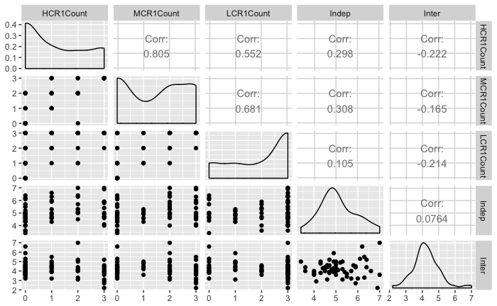

```r
ggpairs(myCorrVariables)
```

On the diagonal, you see density plots for each variable. For example, you can see in the first cell that most people reported their high close friends 0 times. If you look at the last cell, you can see something close to a normal curve for the interdependence scores. In the very middle cell you can see that most people always reported their low close friends.

Above the diagonal, you can see the correlation coefficients. These should be the same as the coefficients created by corr.test() of the psych package.

If you look below the diagonal, you can see a scaterplot of the correlations. **And we see a problem.**

If you look at the scatterplot of the relationship between independence and interdepence, it looks like a bunch of random dots. That’s what it should look like. But if you look at any of the others, you see the dots aren’t random anymore. They tend to bunch up on the values of 0, 1, 2, and 3. **This is a problem.** It means that our counting variable is discrete instead of continuous.

We performed a ‘pearson’ correlation test. Pearson is best for calculating the correlation between two continuos variables. If one of the variables is discrete, as in this case, we should instead perform a ‘spearman’ correlation test.

**Sidenote** This is a great example of the importance of visualizing your data. It was very easy to see that we have discrete data when it was plotted like this.

So the solution is to redo the test but to tell corr.test() that we want spearman correlations, not pearson correlations.

```r
myCorrTest <- corr.test(x=myCorrVariables, y = NULL, use = "pairwise",method="spearman",adjust="holm", alpha=.05,ci=TRUE)
myCorrTest
```

```
Call:corr.test(x = myCorrVariables, y = NULL, use = "pairwise", method = "spearman",
    adjust = "holm", alpha = 0.05, ci = TRUE)
Correlation matrix
          HCR1Count MCR1Count LCR1Count Indep Inter
HCR1Count      1.00      0.83      0.58  0.29 -0.17
MCR1Count      0.83      1.00      0.67  0.27 -0.17
LCR1Count      0.58      0.67      1.00  0.09 -0.23
Indep          0.29      0.27      0.09  1.00  0.01
Inter         -0.17     -0.17     -0.23  0.01  1.00
Sample Size
[1] 65
Probability values (Entries above the diagonal are adjusted for multiple tests.)
          HCR1Count MCR1Count LCR1Count Indep Inter
HCR1Count      0.00      0.00      0.00  0.13  0.67
MCR1Count      0.00      0.00      0.00  0.16  0.67
LCR1Count      0.00      0.00      0.00  0.91  0.36
Indep          0.02      0.03      0.45  0.00  0.92
Inter          0.17      0.19      0.07  0.92  0.00

 To see confidence intervals of the correlations, print with the short=FALSE option
```

Ok, let’s keep exploring the power of r to make great visualizations of data. We will create a plot of one correlation and try to make it look as good as possible.

The package [‘ggplot2’](http://ggplot2.tidyverse.org) is a great way to create plots in R. First, lets load the package.

```r
if (!require(ggplot2)){
  install.packages("ggplot2", dependencies = TRUE)
  require(ggplot2)
}
```

The first step in using ggplot is to tell ggplot() which dataframe we would like to use and which two variables from that dataframe ggplot() should plot.

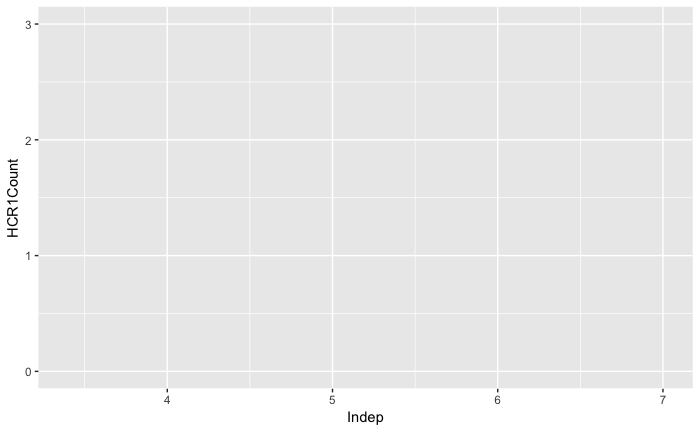

```r
ggplot(myCorrVariables, aes(Indep, HCR1Count))
```

We have a blank grid!

That’s ok. Notice that the names of our variables showed up and ggplot() is smart enough to automatically figure out the appropriate ranges for the x and y axes.

Now we will tell ggplot to put some dots up there!

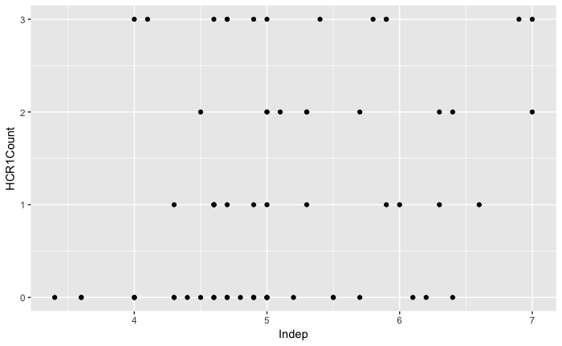

```r
ggplot(myCorrVariables, aes(Indep, HCR1Count)) + geom_point()
```

Ok, now we have a scatterplot! The code to add the dots (or points) is just + geom_point(). With ggplot, the idea is to keep adding ‘layers’ to the plot until everything you want is there.

The code + geom_point() tells ggplot to add a layer of points.

But, it would be nice to see the regression line related to our correlation coefficient. Let’s add that now. We will tell ggplot to add a layer with a regression line.

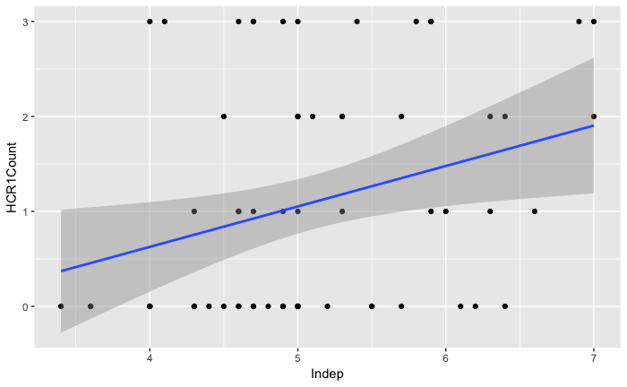

```r
ggplot(myCorrVariables, aes(Indep, HCR1Count)) + geom_point() + geom_smooth(method = lm)
```

Now it is much easier to see the positive (r = .3) relationship between HCR1Count and Indep.

All we had to do to add the line was add: + geom_smooth() to our code. Well, there was one other thing as well. We had to tell ggplot what method ‘smoothing’ we would like. Method = lm tells ggplot we would like a linear regression line.

Also, notice the grey band around the regression line. That is the 95% confidence region for the regression line.

At this point you can see the basic logic of ggplot. Everytime you want to add a plot to the graph you just type: + geom_the name of the layer. A google search will let you know what other types of layers as possible.

So we’ve got everything we need at this point but the labels aren’t useful. They’re ok for us because we know what they mean. But anyone else looking at this plot will have no idea what the variables are. Let’s fix the labels now.

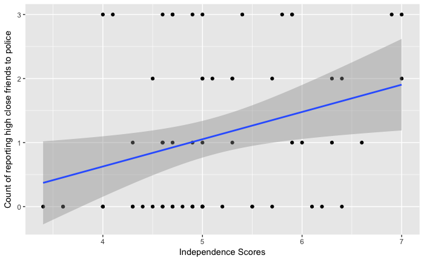

```r
ggplot(myCorrVariables, aes(Indep, HCR1Count)) + geom_point() + geom_smooth(method = lm) + labs(x = "Independence Scores", y = "Count of reporting high close friends to police")
```

Pretty simple. You can add a layer of labels with the code: + labs()

This graph is competent but I wish it looked better. Let’s try getting rid of the gray rectangles in the background. I don’t think we need those and graphs published in psychology journals usually don’t include any background.

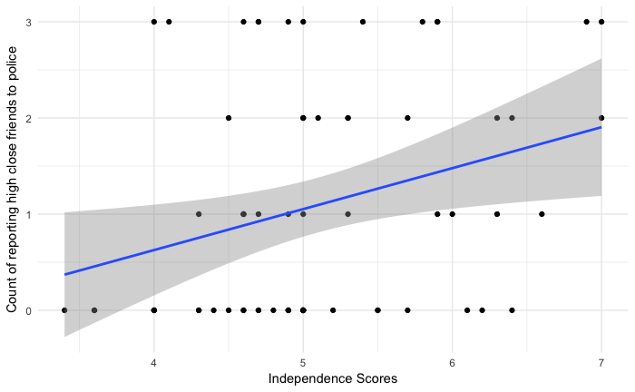

```r
ggplot(myCorrVariables, aes(Indep, HCR1Count)) + geom_point() + geom_smooth(method = lm) + labs(x = "Independence Scores", y = "Count of reporting high close friends to police") + theme_minimal()
```

ggplot() comes preloaded with a number of themes. You can find out what they are via a quick google search. theme_minimal() is a nice plain theme. But not plain enough for me! What are those gray lines doing there? Let’s get rid of them too.

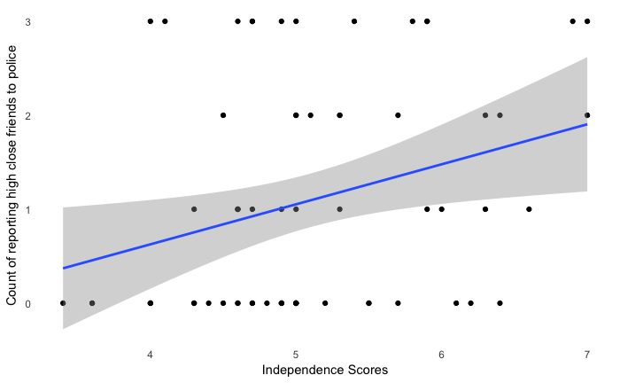

```r
ggplot(myCorrVariables, aes(Indep, HCR1Count)) + geom_point() + geom_smooth(method = lm) + labs(x = "Independence Scores", y = "Count of reporting high close friends to police") + theme_minimal() + theme(panel.grid = element_blank())
```

There we go!

In ggplot() you can make modifications to the general theme with + theme()

But now I’m missing the y and x axes. Let’s try to add them.

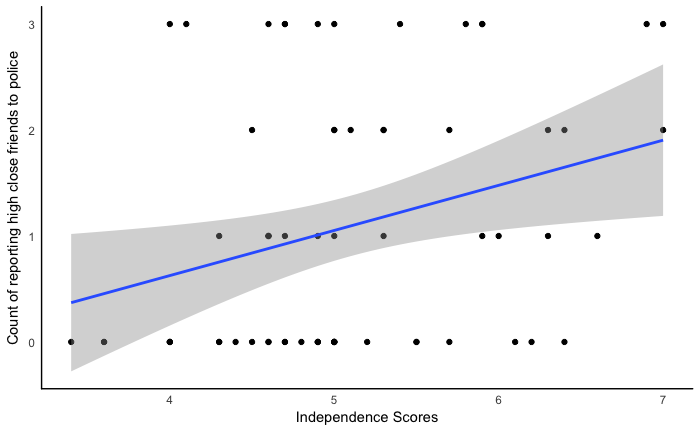

```r
ggplot(myCorrVariables, aes(Indep, HCR1Count)) + geom_point() + geom_smooth(method = lm) + labs(x = "Independence Scores", y = "Count of reporting high close friends to police") + theme_minimal() + theme(panel.grid = element_blank(), axis.line.x = element_line(color="black", size = .5), axis.line.y = element_line(color="black", size = .5))
```

Perfect.

Notice, we can keep adding modifications to the general theme by adding new items to +theme(). We just add a comma and list the next modification. A google search will tell you what options you can add to + theme().

I just noticed something a little off with our scatterplot. There doesn’t appear to be enough dots. We should have 65 dots–one for each participant. Instead, we have fewer than that. I think the problem may be that some of the dots are on top of one another. This can happen when one of the variables is discrete (like ours!). To fix this problem, let’s jitter the location of the dots. Add a geom_jitter() layer.

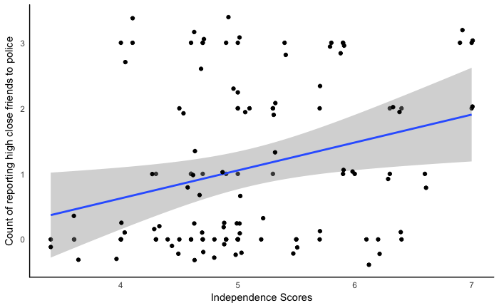

```r
ggplot(myCorrVariables, aes(Indep, HCR1Count)) + geom_point() + geom_smooth(method = lm) + labs(x = "Independence Scores", y = "Count of reporting high close friends to police") + theme_minimal() + theme(panel.grid = element_blank(), axis.line.x = element_line(color="black", size = .5), axis.line.y = element_line(color="black", size = .5)) + geom_jitter()
```

Now we can see all the dots!

Let’s do one last thing to make this graph better for publication in an APA journal that doesn’t do color. Let’s change the blue line to black. Add: color = “black” to the geom_smooth() layer.

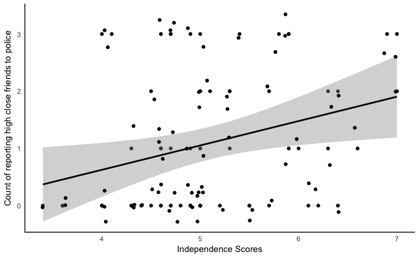

```r
ggplot(myCorrVariables, aes(Indep, HCR1Count)) + geom_point() + geom_smooth(method = lm, color="black") + labs(x = "Independence Scores", y = "Count of reporting high close friends to police") + theme_minimal() + theme(panel.grid = element_blank(), axis.line.x = element_line(color="black", size = .5), axis.line.y = element_line(color="black", size = .5)) + geom_jitter()
```

All ready for publication!